# Multiclass - Classification on Iris dataset

Multiclass classication on iris data set to classify flowers according to different species.

##### Packages in use :

```r
library(caret)           #for model traing
library(dplyr)           #for dataframe operations
library(rattle)           #decision tree model
```

##### Loading dataset from csv file :

Data set “iris” gives the measurements in centimeters of the variables : sepal length, sepal width, petal length, petal width, respectively, for 50 flowers from each of 3 species of Iris.

```r
iris <- read.csv("Iris.csv")
iris <- select(iris,-c(Id))   #removing the Id column
head(iris)                    #shows first 6 rows in dataframe
```

```
##   SepalLengthCm SepalWidthCm PetalLengthCm PetalWidthCm     Species
## 1           5.1          3.5           1.4          0.2 Iris-setosa
## 2           4.9          3.0           1.4          0.2 Iris-setosa
## 3           4.7          3.2           1.3          0.2 Iris-setosa
## 4           4.6          3.1           1.5          0.2 Iris-setosa
## 5           5.0          3.6           1.4          0.2 Iris-setosa
## 6           5.4          3.9           1.7          0.4 Iris-setosa
```

##### Spliting dataset for testing and training :

By using createDataPaartition() from caret package split the dataset into training and testing set.Here I have used a proportion of 80 % for training and rest 20% for the testing purpose.

```r
valid_matrix <- createDataPartition(iris$Species,p=0.80,list=FALSE)

test_set <- iris[-valid_matrix,]   #20% for the test
train_set <- iris[valid_matrix,]   #80% for the train
```

##### Data Analysis on training set:

Viewing the training set to gain insights.

```r
summary(train_set)        #for summery of the dataframe
```

```
##  SepalLengthCm    SepalWidthCm   PetalLengthCm    PetalWidthCm
##  Min.   :4.300   Min.   :2.000   Min.   :1.000   Min.   :0.100
##  1st Qu.:5.100   1st Qu.:2.800   1st Qu.:1.600   1st Qu.:0.300
##  Median :5.800   Median :3.000   Median :4.300   Median :1.300
##  Mean   :5.827   Mean   :3.056   Mean   :3.748   Mean   :1.199
##  3rd Qu.:6.400   3rd Qu.:3.400   3rd Qu.:5.100   3rd Qu.:1.800
##  Max.   :7.900   Max.   :4.400   Max.   :6.900   Max.   :2.500
##             Species
##  Iris-setosa    :40
##  Iris-versicolor:40
##  Iris-virginica :40
##
##
##
```

```r
dim(train_set)            #no. of rows and columns
```

```
## [1] 120   5
```

```r
colnames(train_set)       #column names
```

```
## [1] "SepalLengthCm" "SepalWidthCm"  "PetalLengthCm" "PetalWidthCm"
## [5] "Species"
```

```r
sapply(train_set,class)   #class of each column
```

```
## SepalLengthCm  SepalWidthCm PetalLengthCm  PetalWidthCm       Species
##     "numeric"     "numeric"     "numeric"     "numeric"      "factor"
```

```r
levels(train_set$Species) #levels/catagories in Species
```

```
## [1] "Iris-setosa"     "Iris-versicolor" "Iris-virginica"
```

```r
table(train_set$Species)  #no. of entries in each label
```

```
##
##     Iris-setosa Iris-versicolor  Iris-virginica
##              40              40              40
```

##### Feature Plotings :

Visualising the train set. The y label to predict for this model is Species, which is located at column 5 in the data frame. All other attribute columns are included as features in x

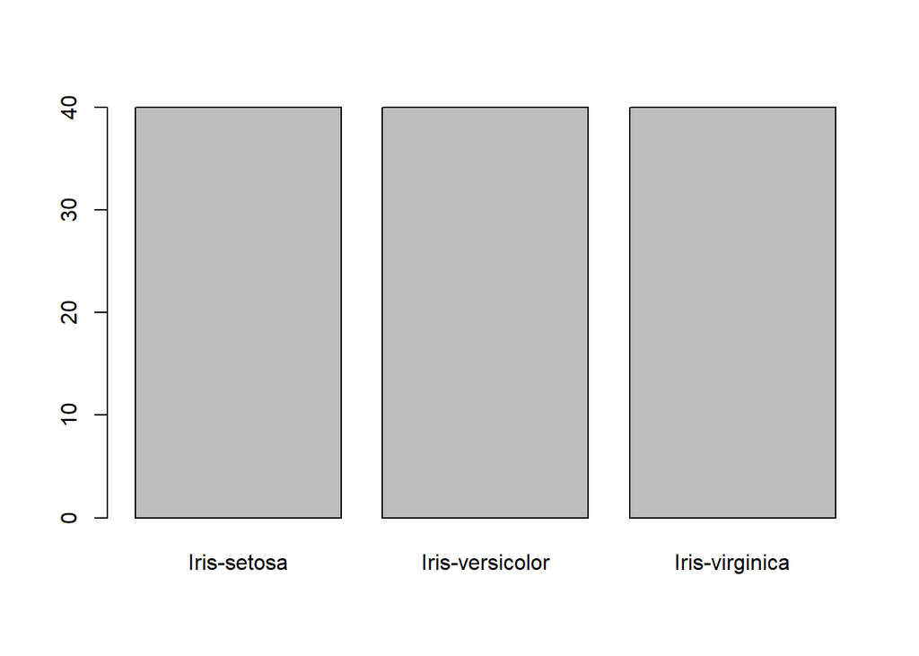

```r
x_set <- train_set[,1:4]
y_set <- train_set[,5]

plot(y_set)
```

Bar plot to check the proportion in each species .There are 40 entries for each species.

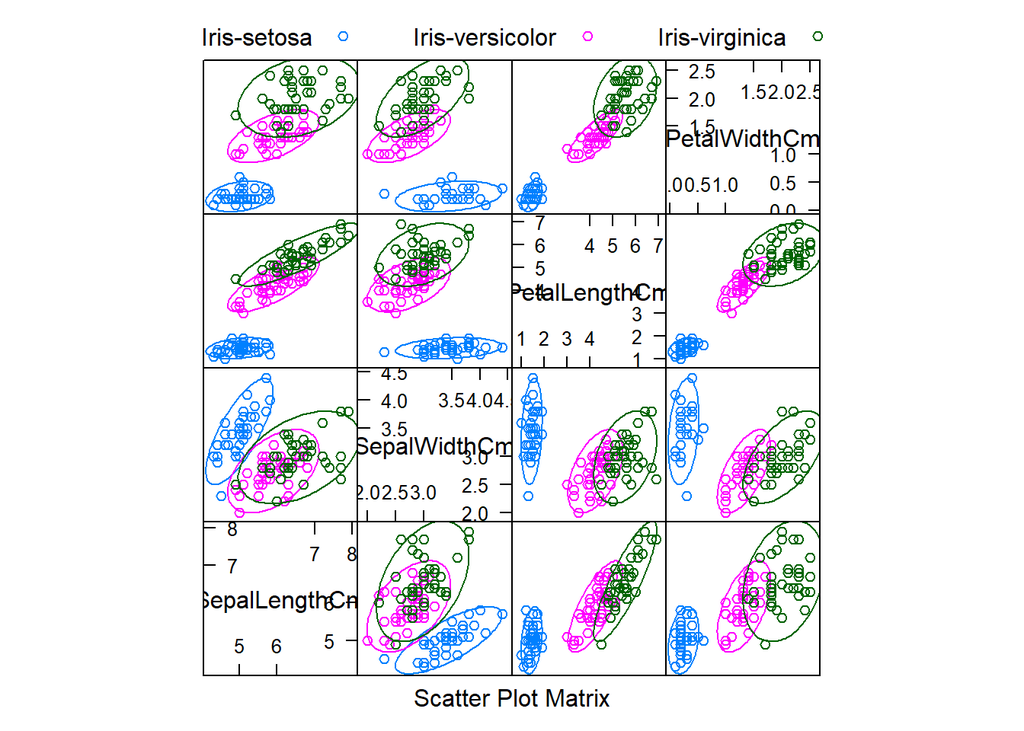

```r
featurePlot(x=x_set,
            y=y_set,
            plot = "ellipse",
            auto.key = list(columns = 3))
```

A Scatter plot matrix to provides a quick and easy view of corelation i.e how much one variable is affected by another.

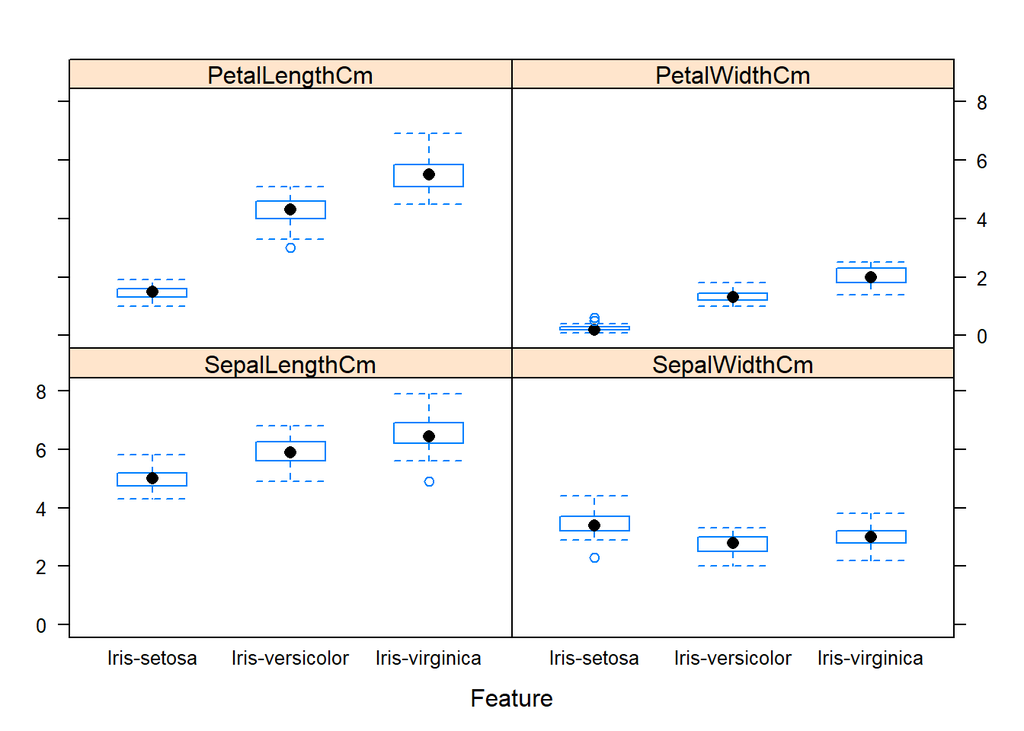

```r
featurePlot(x=x_set,
            y=y_set,
            plot="box")
```

Box plot provides whiskers for each attribute grouped by y class.

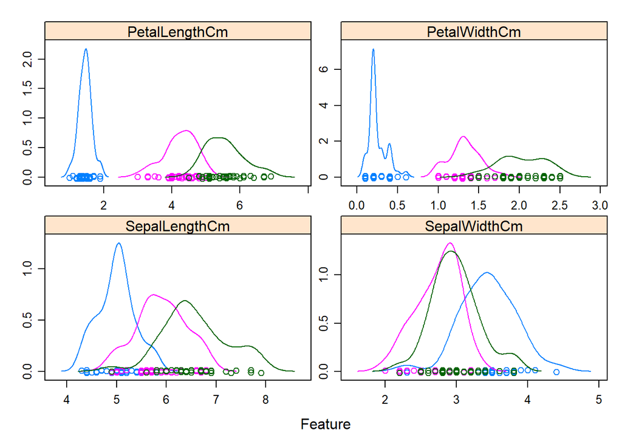

```r
featurePlot(x = x_set,
            y = y_set,
            plot = "density",
            ## Pass in options to xyplot() to
            ## make it prettier
            scales = list(x = list(relation="free"),
                          y = list(relation="free")),
            )
```

Density plot provides density by each attribute in y class.

##### Creating different Machine Learning Models :

Since we have only 150 rows in iris dataset, removing a part of it for validation poses a problem of underfitting. By reducing the training data, we risk losing important patterns/ trends in data set, which in turn increases error induced by bias.So, what we require is a method that provides ample data for training the model and also leaves ample data for validation.

Resampling method used here is K Fold cross validation .The value of K in this case is 10.

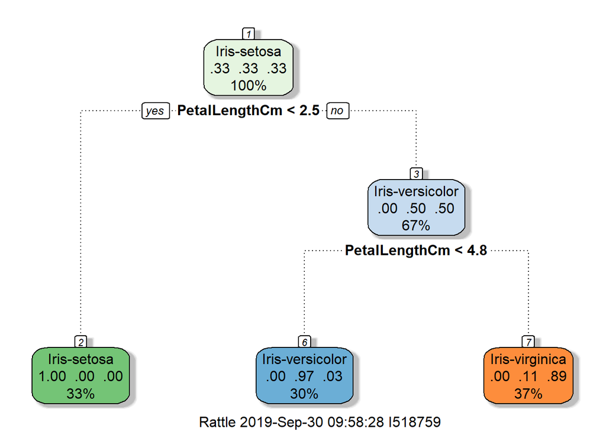

```r
control <- trainControl(method = "cv",number = 10)

#Naive Bayes
set.seed(7)
fit.nb <- train(Species~.,data=train_set,method="nb",trControl= control)

# Classification and Regression Trees
#rpart : non recursive partitioning./decision tree
set.seed(7)
fit.cart <- train(Species~., data=train_set, method="rpart",trControl=control)
fancyRpartPlot(fit.cart$finalModel)
```

```r
#multinom : Logistic Regression
set.seed(7)
fit.multinom <- train(Species~.,data=train_set,method="multinom")
# k-Nearest Neighbors
set.seed(7)
fit.knn <- train(Species~., data=train_set, method="knn",trControl=control)

# Support Vector Machines
set.seed(7)
fit.svm <- train(Species~., data=train_set, method="svmRadial",trControl=control)

#Random Forest
set.seed(7)
fit.rf <- train(Species~., data=train_set, method="rf",trControl= control)

# Linear Discriminant Analysis
set.seed(7)
fit.lda <- train(Species~., data=train_set, method="lda",trControl=control)
```

##### Summerize and finding best model :

Analyzing results from each model and finding out the best one on the basis of metrics. metrics used here is Accuracy and Kappa.

```r
results <- resamples(list(lda=fit.lda,nb=fit.nb, cart=fit.cart, knn=fit.knn, svm=fit.svm, rf=fit.rf))
summary(results)
```

```
##
## Call:
## summary.resamples(object = results)
##
## Models: lda, nb, cart, knn, svm, rf
## Number of resamples: 10
##
## Accuracy
##           Min.   1st Qu.    Median      Mean   3rd Qu. Max. NA's
## lda  0.8333333 1.0000000 1.0000000 0.9750000 1.0000000    1    0
## nb   0.8333333 0.9166667 0.9583333 0.9416667 1.0000000    1    0
## cart 0.8333333 0.9166667 0.9166667 0.9166667 0.9166667    1    0
## knn  0.9166667 0.9166667 0.9583333 0.9583333 1.0000000    1    0
## svm  0.7500000 0.9166667 0.9166667 0.9250000 1.0000000    1    0
## rf   0.8333333 0.9166667 0.9166667 0.9333333 1.0000000    1    0
##
## Kappa
##       Min. 1st Qu. Median   Mean 3rd Qu. Max. NA's
## lda  0.750   1.000 1.0000 0.9625   1.000    1    0
## nb   0.750   0.875 0.9375 0.9125   1.000    1    0
## cart 0.750   0.875 0.8750 0.8750   0.875    1    0
## knn  0.875   0.875 0.9375 0.9375   1.000    1    0
## svm  0.625   0.875 0.8750 0.8875   1.000    1    0
## rf   0.750   0.875 0.8750 0.9000   1.000    1    0
```

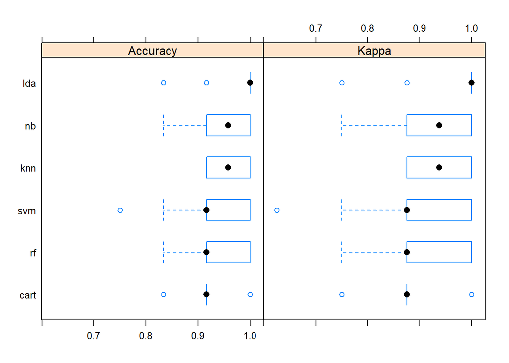

```r
bwplot(results)
```

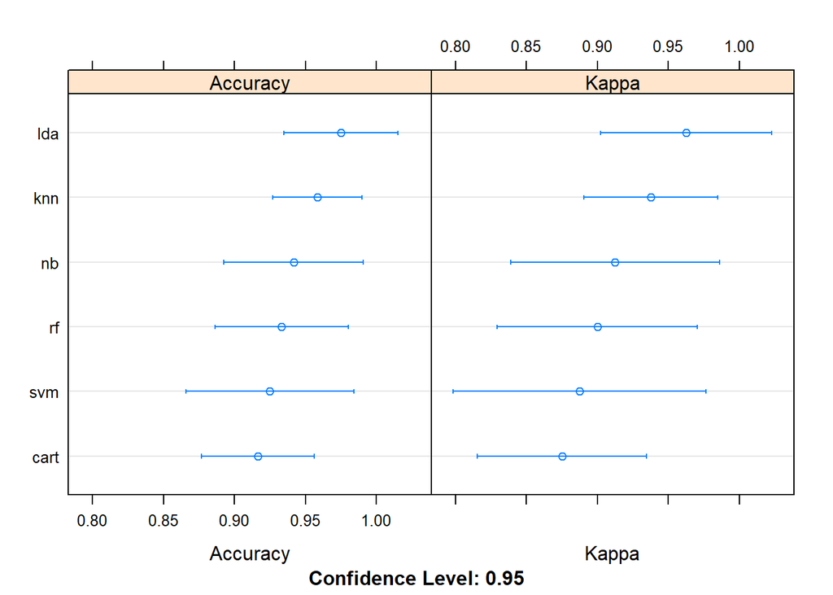

```r
dotplot(results)
```

##### Testing with the best model : Predicting the testing set species

```r
print(fit.lda)
```

```
## Linear Discriminant Analysis
##
## 120 samples
##   4 predictor
##   3 classes: 'Iris-setosa', 'Iris-versicolor', 'Iris-virginica'
##
## No pre-processing
## Resampling: Cross-Validated (10 fold)
## Summary of sample sizes: 108, 108, 108, 108, 108, 108, ...
## Resampling results:
##
##   Accuracy  Kappa
##   0.975     0.9625
```

```r
lda_predict <- predict(fit.lda,test_set)
confusionMatrix(lda_predict,test_set$Species)
```

```
## Confusion Matrix and Statistics
##
##                  Reference
## Prediction        Iris-setosa Iris-versicolor Iris-virginica
##   Iris-setosa              10               0              0
##   Iris-versicolor           0              10              0
##   Iris-virginica            0               0             10
##
## Overall Statistics
##
##                Accuracy : 1
##                  95% CI : (0.8843, 1)
##     No Information Rate : 0.3333
##     P-Value [Acc > NIR] : 4.857e-15
##
##                   Kappa : 1
##
##  Mcnemar's Test P-Value : NA
##
## Statistics by Class:
##
##                      Class: Iris-setosa Class: Iris-versicolor
## Sensitivity                      1.0000                 1.0000
## Specificity                      1.0000                 1.0000
## Pos Pred Value                   1.0000                 1.0000
## Neg Pred Value                   1.0000                 1.0000
## Prevalence                       0.3333                 0.3333
## Detection Rate                   0.3333                 0.3333
## Detection Prevalence             0.3333                 0.3333
## Balanced Accuracy                1.0000                 1.0000
##                      Class: Iris-virginica
## Sensitivity                         1.0000
## Specificity                         1.0000
## Pos Pred Value                      1.0000
## Neg Pred Value                      1.0000
## Prevalence                          0.3333
## Detection Rate                      0.3333
## Detection Prevalence                0.3333
## Balanced Accuracy                   1.0000
```